# Análise Exporatória

## Índice

- Questão 1
  - Item a
  - Item b
  - Item c
  - Item d
  - Item e
- Questão 2
  - Item a
  - Item b
- Questão 3
  - Item a
  - Item b
  - Item c
  - Item d
- Questão 4
  - Item a
  - Item b
  - Item c

```python
%matplotlib inline

import pandas as pd
import numpy as np
import matplotlib.pyplot as plt
```

# Questão 1

[figure not shown]

Um competidor do Kaggle, George McIntire, que se diz ser apaixonado por músicas, ficou curioso para saber porquê ele gosta das músicas que ele gosta. Com isso, ele construiu um conjunto de dados de músicas de 2017 obtido via API do Spotify e rotulou cada música como *"Like"*, o que significa que ele gosta e *"Dont Like"* para músicas que não gosta.

*Fonte: Textos extraídos e/ou adaptados de https://www.kaggle.com/geomack/spotifyclassification.*

Consulte o dicionario de dados no link Dicionário de dados antes de resolver os itens a seguir.

```python
dados_1 = pd.read_excel("arquivos/Q1_Spotify_CD.xlsx")
```

```python
dados_1.head(3)
```

|  | music_id | acousticness | danceability | duration_ms | energy | instrumentalness | liveness | loudness | speechiness | tempo | valence | song_title | artist | liking |
| --- | --- | --- | --- | --- | --- | --- | --- | --- | --- | --- | --- | --- | --- | --- |
| 0 | 0 | 0.0102 | 0.833 | 204600 | 0.434 | 0.021900 | 0.165 | -8.795 | 0.4310 | 150.062 | 0.286 | Mask Off | Future | Like |
| 1 | 1 | 0.1990 | 0.743 | 326933 | 0.359 | 0.006110 | 0.137 | -10.401 | 0.0794 | 160.083 | 0.588 | Redbone | Childish Gambino | Dont Like |
| 2 | 2 | 0.0344 | 0.838 | 185707 | 0.412 | 0.000234 | 0.159 | -7.148 | 0.2890 | 75.044 | 0.173 | Xanny Family | Future | Like |

```python
dados_1.liking = dados_1.liking.astype('category')
```

```python
dados_1.columns
```

```
Index(['music_id', 'acousticness', 'danceability', 'duration_ms', 'energy',
       'instrumentalness', 'liveness', 'loudness', 'speechiness', 'tempo',
       'valence', 'song_title', 'artist', 'liking'],
      dtype='object')
```

**A seção a seguir contém uma análise das variáveis `energy` e `liking`, por favor faça:**

**a)** Construa um histograma de densidade de frequências da variável `energy` separadamente para cada categoria de `liking`.

**Resposta a partir daqui**

i) Gráficos:

```python
dados_1.energy.describe()
```

```
count    2017.000000
mean        0.681577
std         0.210273
min         0.014800
25%         0.563000
50%         0.715000
75%         0.846000
max         0.998000
Name: energy, dtype: float64
```

```python
faixa=np.arange(0,1,0.04)
```

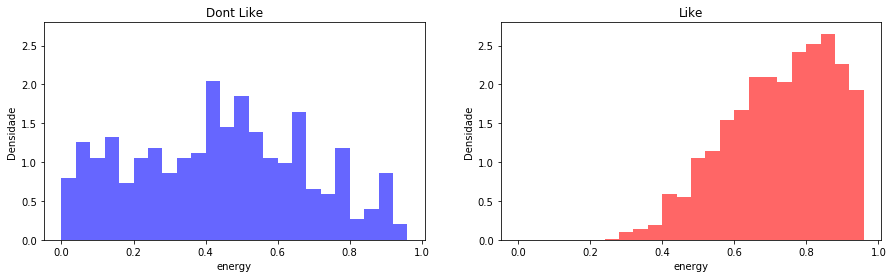

```python
#Uma maneira:

fig = plt.figure(figsize=(15, 4))
plt.subplot(121)
dados_1.energy[dados_1.liking=='Dont Like'].plot.hist(bins=faixa, color=('blue'), density=1, title="Dont Like", alpha=0.6)
plt.ylim(0,2.8)
plt.ylabel('Densidade')
plt.xlabel('energy')

plt.subplot(122)
dados_1.energy[dados_1.liking=='Like'].plot.hist(bins=faixa, color=('red'), density=1, title="Like", alpha=0.6)
plt.ylim(0,2.8)
plt.ylabel('Densidade')
plt.xlabel('energy')

plt.show()
```

**b)** Interprete os histogramas do item anterior em termos da preferência de George. Existe alguma tendência ou orientação em suas preferências?

**Resposta a partir daqui**

**c)** Observando o formato de cada histograma construído anteriormente e utilizando medidas de posição ou centralidade adequadamente, classifique como sendo simétrico, assimétrico a direita ou assimétrico a esquerda. Argumente claramente o motivo de sua classificação. Apresente as referidas medidas de posição (tendência central)

**Resposta a partir daqui**

Formato do gráfico com uso de medidas de posição!

```python
dados_1.energy[dados_1.liking=="Dont Like"].describe()
```

```
count    381.000000
mean       0.439961
std        0.244511
min        0.014800
25%        0.247000
50%        0.445000
75%        0.629000
max        0.965000
Name: energy, dtype: float64
```

```python
dados_1.energy[dados_1.liking=="Like"].describe()
```

```
count    1636.000000
mean        0.737846
std         0.154438
min         0.256000
25%         0.630000
50%         0.756500
75%         0.862000
max         0.998000
Name: energy, dtype: float64
```

**Análise das variáveis energy e loudness**

Neste item, considere as variáveis `energy` e `loudness` (utilize todas as faixas sem separar por `liking`).

A partir dos dados, faça:

**d)** Apresente um **gráfico** adequado que permita visualizar a associação entre as variáveis `energy` e `loudness`. Discuta se há uma associação aparente a partir do gráfico

**Resposta a partir daqui**

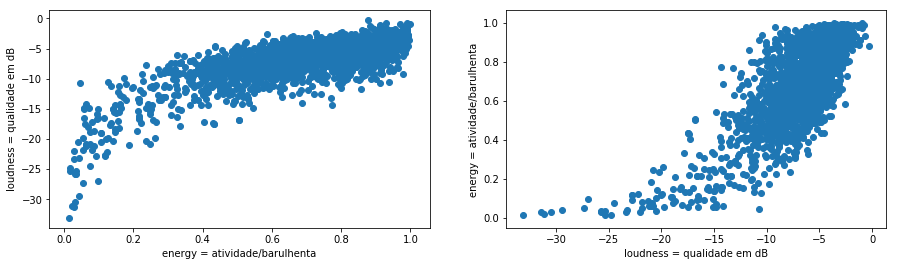

```python
fig = plt.figure(figsize=(15, 4))
plt.subplot(121)
plt.scatter(dados_1.energy, dados_1.loudness)
plt.xlabel('energy = atividade/barulhenta')
plt.ylabel('loudness = qualidade em dB')

plt.subplot(122)
plt.scatter(dados_1.loudness, dados_1.energy)
plt.ylabel('energy = atividade/barulhenta')
plt.xlabel('loudness = qualidade em dB');
```

Nota-se que quanto mais barulhenta (alta energia) for uma faixa maior, tende a ser sua qualidade (dB tendendo a zero). Uma faixa com qualidade abaixo de -20, tende a ter energia mais próxima de zero.

**e)** Utilizando uma **medida-resumo** adequada, discuta o grau de associação dessas duas variáveis: `energy` e `loudness`.

**Resposta a partir daqui**

```python
dados_1.energy.corr(dados_1.loudness)
```

```
0.7621769711494923
```

Como já notado graficamente, observa-se que há uma forte associação positiva entre essas duas variáveis (0,76), ainda que não seja necessariamente apenas linear.

# Questão 2

### Dados da PNAD 2015

Mulher Brasileira Chefe de Família. Que Mulher é essa?

Assuma que haja o interesse em descrever o perfil das mulheres casadas e chefes de família<sup>1</sup> no ano de 2015 contrapondo àquelas que também são casadas e trabalham, mas não assumem esse papel na família.

A base de dados que terá acesso traz informações exclusivamente de uma amostra restrita de mulheres casadas que possuem as seguintes características:

✔ Todas possuem **pelo menos um trabalho principal** no dia da pesquisa;

✔ São **todas casadas** e têm **idade entre 20 a 59 anos**;

✔ Todas possuem **rendimento do trabalho principal entre R\$ 200,00 e R\\$ 5.000,00**;

✔ Cada mulher tem classificada **sua condição na família** bem definida na data da pesquisa: **Chefe** ou **Não chefe**.

<sup>1</sup>*Indivíduo que se declara como “pessoa de referência” na família.*

O arquivo **pnadMulher.xlsx** traz informações das seguintes variáveis:

- **REGIAO – indica a região de residência da mulher** * categorias: ('Norte', 'Nordeste', 'Sul', 'Sudeste', 'Centro-Oeste') - **AREA – indica a situação censitária da residência da mulher** * categorias: ('Rural', 'Urbana') - **CONDFAM – corresponde a condição da mulher na famíli** * categorias: ('Chefe','Nao chefe') - **IDADE – idade da mulher**, em anos - **CORRACA – cor ou raça da mulher** * categorias: ('Indigena', 'Branca', 'Preta', 'Amarela', 'Parda') - **NATUNIAO – natureza da união** * categorias: ('Casamento civil e religioso', 'So casamento civil', 'So casamento religioso','Uniao consensual') - **NIVELINST – nível de instrução mais elevado alcançado pela mulher** * categorias: ('Sem instrucao', 'Fundamental incompleto', 'Fundamental completo', 'Medio incompleto', 'Medio completo', 'Superior incompleto', 'Superior completo', 'Nao determinado') - **OCUPACAO – ocupação da mulher no trabalho principal** * categorias: ('Empregado', 'Trabalhador domestico', 'Conta propria', 'Empregador') - **ANOSTRAB – número de anos no trabalho principal**, em anos - **HORASTRABSEMANA – horas habitualmente trabalhadas por semana em todos os trabalhos** * categorias: ('Ate 14 horas', '15 a 39 horas', '40 a 44 horas', '45 a 48 horas', '49 horas ou mais') - **RENDTRABPRINC – rendimento mensal do trabalho principal da mulher**, em reais - **RENDTRABTODOS – rendimento mensal de todos os trabalhos da mulher**, em reais - **RENDFAMPERCAPITA – rendimento mensal familiar per capita – soma todas as rendas da família**, em reais

```python
dados = pd.read_excel("arquivos/pnadMulher.xlsx")
```

```python
dados.head()
```

|  | REGIAO | AREA | CONDFAM | IDADE | CORRACA | NATUNIAO | NIVELINST | OCUPACAO | ANOSTRAB | HORASTRABSEMANA | RENDTRABPRINC | RENDTRABTODOS | RENDFAMPERCAPITA |
| --- | --- | --- | --- | --- | --- | --- | --- | --- | --- | --- | --- | --- | --- |
| 0 | Norte | Urbana | Chefe | 35 | Parda | So casamento civil | Superior incompleto | Empregado | 0 | 40 a 44 horas | 880 | 880 | 793 |
| 1 | Norte | Urbana | Chefe | 34 | Parda | Uniao consensual | Medio completo | Empregado | 0 | 40 a 44 horas | 790 | 790 | 818 |
| 2 | Norte | Urbana | Nao chefe | 51 | Parda | So casamento civil | Medio completo | Empregador | 11 | 40 a 44 horas | 2000 | 2000 | 1716 |
| 3 | Norte | Urbana | Nao chefe | 20 | Parda | Uniao consensual | Medio incompleto | Empregado | 0 | 40 a 44 horas | 850 | 850 | 666 |
| 4 | Norte | Urbana | Chefe | 49 | Parda | Uniao consensual | Fundamental incompleto | Conta propria | 9 | 45 a 48 horas | 2500 | 2500 | 1662 |

```python
dados.dtypes
```

```
REGIAO              object
AREA                object
CONDFAM             object
IDADE                int64
CORRACA             object
NATUNIAO            object
NIVELINST           object
OCUPACAO            object
ANOSTRAB             int64
HORASTRABSEMANA     object
RENDTRABPRINC        int64
RENDTRABTODOS        int64
RENDFAMPERCAPITA     int64
dtype: object
```

#### Assuma que o objetivo para trabalhar com a base de dados aqui descrita seja:

#### “Analisar se as mulheres com condição de chefe e de não chefe na família possuem o mesmo perfil com relação à idade”

**a)** Utilizando alguma ferramenta estatística que seja adequada, construa um **gráfico** que permita analisar como a idade pode ser semelhante ou não entre as mulheres com condição de chefe e de não chefe na família. Ainda, interprete o gráfico em termos do problema (de forma clara e sucinta).

**Resposta:**

A seguir, há algumas opções gráficas corretas que podem ser consideradas para responder tal objetivo.

```python
faixa=range(20,61,2)
```

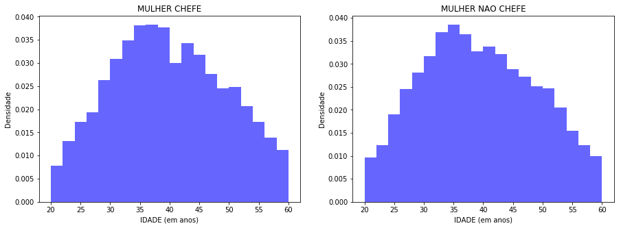

```python
#Uma maneira:

fig = plt.figure(figsize=(15, 5))
plt.subplot(121)
dados.IDADE[dados.CONDFAM=='Chefe'].plot.hist(bins=faixa,
                                                      color=('blue'), density=1,
                                                      title="MULHER CHEFE", alpha=0.6)
plt.ylabel('Densidade')
plt.xlabel('IDADE (em anos)')

plt.subplot(122)
dados.IDADE[dados.CONDFAM=='Nao chefe'].plot.hist(bins=faixa,
                                                          color=('blue'), density=1,
                                                          title="MULHER NAO CHEFE", alpha=0.6)
plt.ylabel('Densidade')
plt.xlabel('IDADE (em anos)')

plt.show()
```

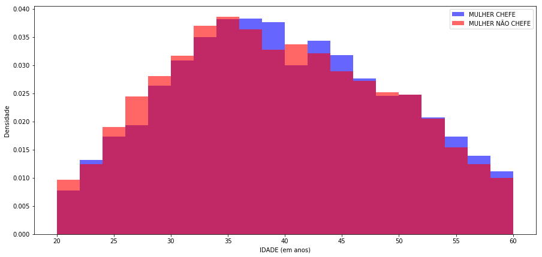

```python
fig = plt.figure(figsize=(15, 7))
plt.subplot(111)
dados.IDADE[dados.CONDFAM=='Chefe'].plot.hist(bins=faixa,
                                                      color=('blue'), density=1, alpha=0.6)
dados.IDADE[dados.CONDFAM=='Nao chefe'].plot.hist(bins=faixa,
                                                          color=('red'), density=1, alpha=0.6)

plt.ylabel('Densidade')
plt.xlabel('IDADE (em anos)')
plt.legend(('MULHER CHEFE', 'MULHER NÃO CHEFE'))
plt.show()
```

**Interpretação:**

Descrever de forma clara e sucinta como IDADE tem suas diferenças ANALISANDO gráfico.

Um exemplo: Histograma construído com `bins` adequados mostrará que mulheres chefes são mais concentradas entre 34 a 40 anos e mulheres não chefes, entre 32 a 38 anos. Ainda, que entre 24 a 36 anos, mulheres não chefes são mais frequentes dos que mulheres chefes. Já entre 54 a 59 anos, mulheres chefes são mais frequentes do que as não chefes. De maneira geral, há uma maior concentração de mulheres chefes em idades mais altas do que as não chefes.

#### Assuma que o objetivo para trabalhar com a base de dados aqui descrita seja:

#### Prever a renda mensal familiar per capita em função da renda mensal do trabalho principal da mulher com condição de chefe ne família.”.

**b)** Faça um gráfico adequado que permita visualizar como é a associação entre as variáveis renda mensal familiar per capita e renda mensal do trabalho principal, considerando apenas as mulheres com condição de chefe na família. Ainda, interprete o gráfico em termos do problema (de forma clara e sucinta).

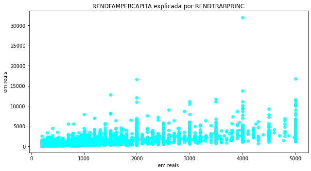

```python
fig = plt.figure(figsize=(9, 5))

plt.scatter(dados.RENDTRABPRINC[dados.CONDFAM=="Chefe"], dados.RENDFAMPERCAPITA[dados.CONDFAM=="Chefe"], c='cyan', alpha=0.8)
plt.title('RENDFAMPERCAPITA explicada por RENDTRABPRINC')
plt.xlabel('em reais')
plt.ylabel('em reais')

plt.tight_layout()
plt.show()
```

**c)** Calcule uma medida adequada que permita interpretar o grau de associação entre as variáveis renda mensal familiar per capita e renda mensal do trabalho principal, considerando apenas as mulheres com condição de chefe na família.

```python
print(dados.RENDFAMPERCAPITA[dados.CONDFAM=="Chefe"].corr(dados.RENDTRABPRINC[dados.CONDFAM=="Chefe"]))
```

```
0.6233913998885166
```

**Interpretação:** PARA PROVA, APENAS **MULHERES CHEFES**

i) Descrever associação positiva visualizada em gráfico de dispersão, considerando obrigatoriamente variável `RENDTRABPRINC` em eixo x e `RENDFAMPERCAPITA` em eixo y.

ii) Correlação entre `RENDTRABPRINC` e `RENDFAMPERCAPITA`.

# QUESTÃO 3

### Análise do ENEM

Esta parte da avaliação se baseia em uma amostra de dados do **ENEM 2017** adaptados para esta prova. O dicionario de dados encontra-se no link a seguir:

Dicionário de dados

```python
filename = "arquivos/enem2017_30K.csv"
dados = pd.read_csv(filename, index_col=0)
dados.head(5)
```

|  | NU_INSCRICAO | SG_UF_RESIDENCIA | NU_IDADE | TP_SEXO | TP_ESTADO_CIVIL | TP_ST_CONCLUSAO | IN_TREINEIRO | NU_NOTA_CN | NU_NOTA_CH | NU_NOTA_LC | ... | CARRO | CELULAR | FIXO | COMPUTADOR | INTERNET | Q026 | TIPO_EM | RENDA | NOTA_TESTES | NOTA_ENEM |
| --- | --- | --- | --- | --- | --- | --- | --- | --- | --- | --- | --- | --- | --- | --- | --- | --- | --- | --- | --- | --- | --- |
| 171957 | 170003469518 | MT | 26.0 | F | 0.0 | 1 | 0 | 605.4 | 657.4 | 542.4 | ... | A | E | A | B | A | A | C | 3020.091575 | 2430.9 | 2990.9 |
| 127898 | 170005286919 | CE | 17.0 | M | 0.0 | 2 | 0 | 698.5 | 649.0 | 630.6 | ... | C | B | A | B | B | B | D | 3611.589780 | 2817.1 | 3677.1 |
| 132925 | 170005113172 | MA | 21.0 | M | 0.0 | 1 | 0 | 591.0 | 643.8 | 597.9 | ... | A | D | A | B | B | A | A | 1375.454182 | 2385.8 | 3325.8 |
| 119870 | 170005346442 | PR | 17.0 | F | 0.0 | 2 | 0 | 525.6 | 441.2 | 509.4 | ... | B | C | A | B | B | B | A | 2079.516469 | 1930.0 | 2450.0 |
| 122904 | 170004476042 | DF | 26.0 | F | 0.0 | 1 | 0 | 538.0 | 408.8 | 523.9 | ... | B | C | A | A | A | A | A | 1364.095119 | 1921.8 | 2381.8 |

5 rows × 28 columns

**a)** Apresente uma tabela cruzada que mostre a escolaridade do pai cruzada com o tipo do ensino médio. Aponte a combinação de categorias mais frequente e, baseado no dicionário de dados, explique o que são.

```python
ct = pd.crosstab(dados.ESC_PAI, dados.TIPO_EM, normalize=True)
```

```python
ct*100
```

| TIPO_EM ESC_PAI | A | B | C | D | E |
| --- | --- | --- | --- | --- | --- |
| A | 5.033333 | 0.063333 | 0.056667 | 0.063333 | 0.046667 |
| B | 20.523333 | 0.393333 | 0.260000 | 0.436667 | 0.253333 |
| C | 13.223333 | 0.356667 | 0.206667 | 0.630000 | 0.273333 |
| D | 10.450000 | 0.423333 | 0.170000 | 0.996667 | 0.320000 |
| E | 18.220000 | 1.220000 | 0.483333 | 4.466667 | 1.070000 |
| F | 3.033333 | 0.420000 | 0.113333 | 3.333333 | 0.460000 |
| G | 1.193333 | 0.253333 | 0.056667 | 2.653333 | 0.256667 |
| H | 7.643333 | 0.250000 | 0.090000 | 0.443333 | 0.160000 |

O crosstab mostra que $20.53\%$ das pessoas têm escolaridade do pai `B`, ou seja, não completou o 5.o ano do fundamental ao mesmo tempo que tipo do ensino médio `A`, ou seja, estuda em escola pública.

**b)** Baseado nos dados, encontre a idade da mulher mais idosa que prestou a prova

```python
max(dados[dados.TP_SEXO=="F"].NU_IDADE)
```

```
74.0
```

**c)** Avalie a afirmação: pessoas com mais renda tendem a ir melhor no ENEM

É necessário:

- realizar o plot de dispersão renda versus pontuação

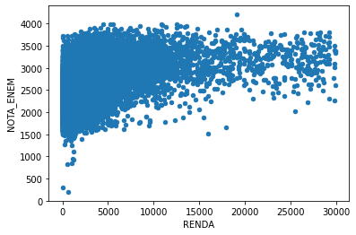

```python
dados.plot.scatter(x="RENDA", y="NOTA_ENEM")
```

```python
dados.RENDA.corr(dados.NOTA_ENEM)
```

```
0.4081900792396614
```

Existe uma correlação de intensidade média entre `RENDA` e `NOTA_ENEM`. O valor do coeficiente de correlação é `0.4`

Nota-se no gráfico que as notas do ENEM variam bastante em todos os níveis de renda

**d)** Compare as várias categorias do ensino médio. Use um recurso gráfico que permita visualizar a distribuição das notas do ENEM comparando as categorias de ensino médio.

- A Somente em escola pública.
- B Parte em escola pública e parte em escola privada SEM bolsa de estudo integral.
- C Parte em escola pública e parte em escola privada COM bolsa de estudo integral.
- D Somente em escola privada SEM bolsa de estudo integral.
- E Somente em escola privada COM bolsa de estudo integral.

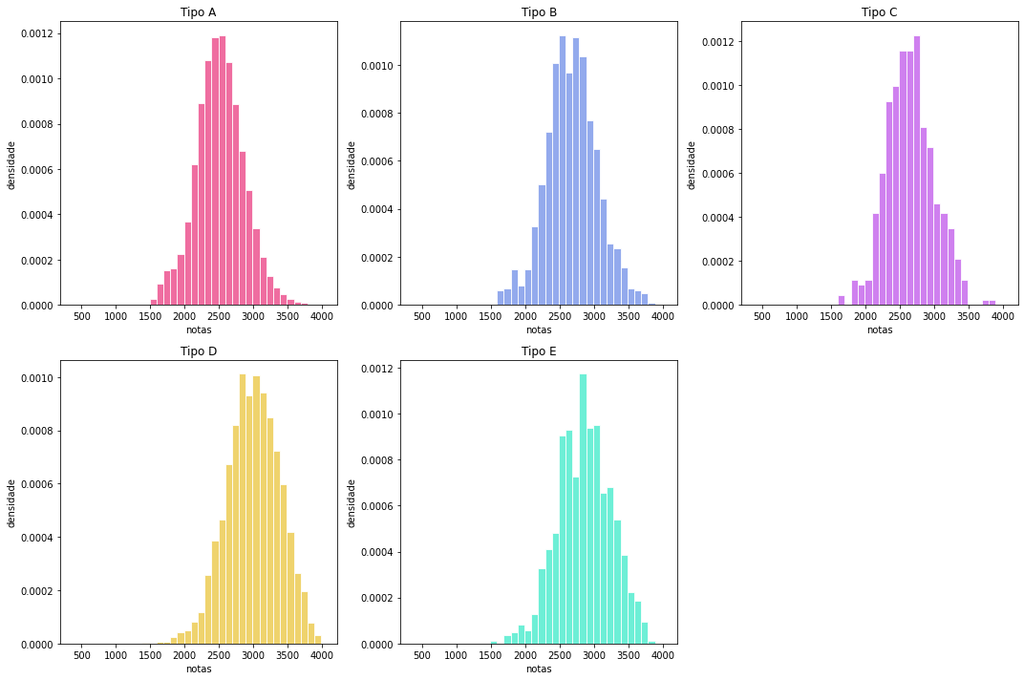

```python
# PROF
from numpy import arange
minimo = dados.NOTA_ENEM.min() - 10
maximo = dados.NOTA_ENEM.max() + 10
faixa = arange(minimo,maximo,100)
plt.figure(figsize=(15, 10))

############################################################
plt.subplot(231)
plt.hist(dados.loc[dados.TIPO_EM == "A","NOTA_ENEM"],
         edgecolor='white',density=True, color='#EC4889',
         linewidth=1, alpha=0.8, bins=faixa)
plt.ylabel('densidade')
plt.xlabel('notas')
plt.title("Tipo A")
plt.xlim(minimo,maximo)

############################################################
plt.subplot(232)
plt.hist(dados.loc[dados.TIPO_EM == "B","NOTA_ENEM"],
         edgecolor='white', density=True, color='#7895E9',
         linewidth=1, alpha=0.8, bins=faixa)
plt.ylabel('densidade')
plt.xlabel('notas')
plt.title("Tipo B")
plt.xlim(minimo,maximo)

############################################################
plt.subplot(233)
plt.hist(dados.loc[dados.TIPO_EM == "C","NOTA_ENEM"],
        edgecolor='white', density=True, color='#C361EB',
        linewidth=1, alpha=0.8, bins=faixa)
plt.ylabel('densidade')
plt.xlabel('notas')
plt.title("Tipo C")
plt.xlim(minimo,maximo)

############################################################
plt.subplot(234)
plt.hist(dados.loc[dados.TIPO_EM == "D","NOTA_ENEM"],
         edgecolor='white', density=True, color='#ECC948',
        linewidth=1, alpha=0.8, bins=faixa)
plt.ylabel('densidade')
plt.xlabel('notas')
plt.title("Tipo D")
plt.xlim(minimo,maximo)

############################################################
plt.subplot(235)
plt.hist(dados.loc[dados.TIPO_EM == "E","NOTA_ENEM"],
        edgecolor='white', density=True, color='#48ECCC',
        linewidth=1, alpha=0.8, bins=faixa)
plt.ylabel('densidade')
plt.xlabel('notas')
plt.title("Tipo E")
plt.xlim(minimo,maximo)

plt.tight_layout()
plt.show()
```

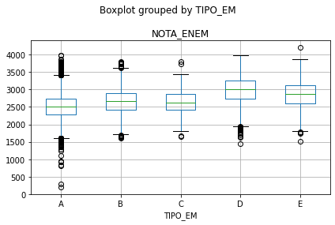

```python
#Outra maneira:
plt.figure(figsize=(25,25))
dados.boxplot(column="NOTA_ENEM", by="TIPO_EM")
plt.tight_layout()
plt.show()
```

Resposta: Existe diferença entre os tipos de ensino médio de acordo com a nota no ENEM. Em particular, podemos ressaltar que:

- Alunos de escolas privadas tendem a ter maiores notas do que alunos da rede publica de ensino, ou aqueles que cursaram parte de seu estudo na rede publica.
- Alunos bolsistas da rede privada tendem a ter notas menores no ENEM que alunos sem bolsa, mas essa diferença não é muito grande.

# KAGGLE:

[figure not shown]

O [Kaggle.com](https://www.kaggle.com/competitions) é um site de competições internacionais de Data Science no qual empresas oferecem prêmios para os analistas que fizerem a melhor modelagem preditiva de diversos problemas.

Em uma das competições recente, o desafio era:

> Ask a home buyer to describe their dream house, and they probably won't begin with the height of the basement ceiling or the proximity to an east-west railroad. But this playground competition's dataset proves that much more influences price negotiations than the number of bedrooms or a white-picket fence.

> With 79 explanatory variables describing (almost) every aspect of residential homes in Ames, Iowa, this competition challenges you to predict the final price of each home.

A seguir, vocês receberão um conjunto de dados bem menor em termos de número de variáveis disponível no Kaggle.

## SIGNIFICADO DAS VARIÁVEIS

A base de dados que terão acesso traz informações de 1460 imóveis cujas variáveis selecionadas possuem as seguintes descrições traduzidas (mantendo os nomes das variáveis e das categorias do problema original - em inglês):

✔ **Id:** número que identifica o imóvel na base de dados.

✔ **SalePrice:** preço de venda da propriedade (em dólares). Ess a é a variável alvo que você irá tentar predizer.

✔ **Foundation:** tipo de fundação, com as seguintes categorias:

- BrkTil - Tijolo e telha
- CBlock - Bloco de concreto
- PConc - Concreto usinado
- Slab - Laje
- Stone - Pedra
- Wood - Madeira

✔ **OverallQual**: avalia de maneira geral o material e o acabamento da casa, com as seguintes categorias:

- Very Poor - Péssimo
- Poor - Ruim
- Fair - Justo
- Below Average - Abaixo da média
- Average - Médio
- Above Average - Acima da média
- Good - Bom
- Very Good - Muito bom
- Excellent - Excelente
- Very Excellent - Muito excelente

✔ **LotArea:** tamanho do lote (em pés quadrados).

✔ **X1stFlrSF:** tamanho do primeiro andar (em pés quadrados).

✔ **X2ndFlrSF:** tamanho do segundo andar (em pés quadrados).

✔ **GarageCars:** tamanho da garagem em capacidade de carros (número de carros).

✔ **Fireplaces:** número de lareiras.

✔ **Street:** tipo de acesso rodoviário à propriedade, com as seguintes categorias:

- Grvl - Cascalho
- Pave - Pavimentado

✔ **LandSlope:** inclinação da propriedade, com as seguintes categorias:

- Gtl - inclinação suave
- Mod - inclinação moderada
- Sev - severo decline

✔ **RoofStyle:** tipo do telhado, com as seguintes categorias:

- Flat - Telhado plano
- Gable - Telhado de duas águas
- Gambrel - Telhado estilo celeiro
- Hip - Telhado de ripa
- Mansard - Mansarda
- Shed - Galpão

✔ **CentralAir:** ar condicionado central, com as seguintes categorias:

- N - Não
- Y - Sim

✔ **YearBuilt:** ano da construção do imóvel.

✔ **YrSold:** ano de venda do imóvel.

O arquivo <house.xlsx > traz todas essas 15 variáveis.

```python
dados = pd.read_excel("arquivos/house.xlsx")
```

```python
dados.head()
```

|  | Id | SalePrice | Foundation | OverallQual | LotArea | X1stFlrSF | X2ndFlrSF | GarageCars | Fireplaces | Street | LandSlope | RoofStyle | CentralAir | YearBuilt | YrSold |
| --- | --- | --- | --- | --- | --- | --- | --- | --- | --- | --- | --- | --- | --- | --- | --- |
| 0 | 1 | 208500 | PConc | Good | 8450 | 856 | 854 | 2 | 0 | Pave | Gtl | Gable | Y | 2003 | 2008 |
| 1 | 2 | 181500 | CBlock | Above Average | 9600 | 1262 | 0 | 2 | 1 | Pave | Gtl | Gable | Y | 1976 | 2007 |
| 2 | 3 | 223500 | PConc | Good | 11250 | 920 | 866 | 2 | 1 | Pave | Gtl | Gable | Y | 2001 | 2008 |
| 3 | 4 | 140000 | BrkTil | Good | 9550 | 961 | 756 | 3 | 1 | Pave | Gtl | Gable | Y | 1915 | 2006 |
| 4 | 5 | 250000 | PConc | Very Good | 14260 | 1145 | 1053 | 3 | 1 | Pave | Gtl | Gable | Y | 2000 | 2008 |

```python
dados.dtypes
```

```
Id              int64
SalePrice       int64
Foundation     object
OverallQual    object
LotArea         int64
X1stFlrSF       int64
X2ndFlrSF       int64
GarageCars      int64
Fireplaces      int64
Street         object
LandSlope      object
RoofStyle      object
CentralAir     object
YearBuilt       int64
YrSold          int64
dtype: object
```

```python
dados.Foundation = dados.Foundation.astype('category')
dados.OverallQual = dados.OverallQual.astype('category')
dados.Street = dados.Street.astype('category')
dados.LandSlope = dados.LandSlope.astype('category')
dados.RoofStyle = dados.RoofStyle.astype('category')
dados.CentralAir = dados.CentralAir.astype('category')

dados.Foundation.cat.categories = (['BrkTil','CBlock','PConc','Slab','Stone','Wood'])
dados.OverallQual.cat.categories = (['Very Poor','Poor','Fair','Below Average','Average',
                                     'Above Average','Good','Very Good','Excellent','Very Excellent'])

dados.Street.cat.categories = (['Grvl','Pave'])
dados.LandSlope.cat.categories = (['Gtl','Mod','Sev'])
dados.RoofStyle.cat.categories = (['Flat','Gable','Gambrel','Hip','Mansard','Shed'])
dados.CentralAir.cat.categories = (['N','Y'])
```

# Questão 4

#### Assuma que o objetivo para trabalhar com a base de dados acima seja: “Analisar como uma determinada variável pode impactar sobre o preço de vendas de um imóvel”.

**a)** Utilizando alguma ferramenta estatística (**gráfica**) que seja adequada, analise como a presença ou não de ar central no imóvel (variável `CentralAir`) pode impactar sobre preço de vendas de um imóvel (variável `SalePrice`). A interpretação precisa ser completa PORÉM sucinta.

```python
dados.SalePrice.describe()
```

```
count      1460.000000
mean     180921.195890
std       79442.502883
min       34900.000000
25%      129975.000000
50%      163000.000000
75%      214000.000000
max      755000.000000
Name: SalePrice, dtype: float64
```

```python
faixa=range(34000,800000,50000)
```

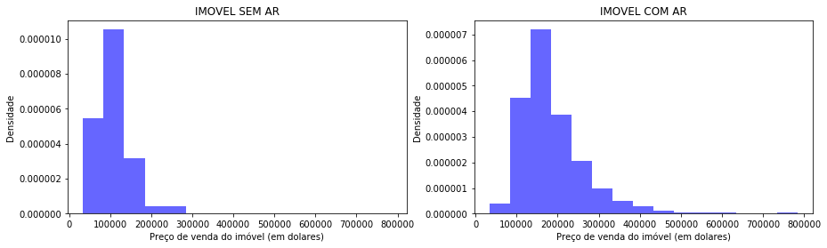

```python
#Uma maneira:

fig = plt.figure(figsize=(15, 4))
plt.subplot(121)
dados.SalePrice[dados.CentralAir=='N'].plot.hist(bins=faixa, color=('blue'), density=True, title="IMOVEL SEM AR", alpha=0.6)
plt.ylabel('Densidade')
plt.xlabel('Preço de venda do imóvel (em dolares)')

plt.subplot(122)
dados.SalePrice[dados.CentralAir=='Y'].plot.hist(bins=faixa, color=('blue'), density=True, title="IMOVEL COM AR", alpha=0.6)
plt.ylabel('Densidade')
plt.xlabel('Preço de venda do imóvel (em dolares)')

plt.show()
```

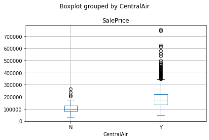

```python
#Outra maneira:
dados.boxplot(column="SalePrice",by="CentralAir")
plt.tight_layout()
plt.show()
```

```python
#Descrever da forma mais completa como presença de Air Central pode predizer preços de imoveis maiores do que sem Ar Central.
#Deixar claro que é maior em média, ou em a partir da haste superior do SEM AR encontra-se possiveis aberrantes enquanto que nos imoveis
#COM AR encontra-se 50% dos imoveis mais caros.
```

#### Assuma que o objetivo para trabalhar com a base de dados acima seja: “Analisar como uma determinada variável pode impactar sobre o preço de vendas de um imóvel”.

**b)** Utilizando alguma ferramentas estatísticas (**numérica** E **gráfica**) que sejam adequadas, analise como o tamanho de área construída do primeiro andar do imóvel (variável `X1stFlrSF`) pode impactar sobre preço de vendas do mesmo (variável `SalePrice`). A interpretação precisa ser completa PORÉM sucinta.

```python
dados.SalePrice.corr(dados.X1stFlrSF)
```

```
0.6058521846919146
```

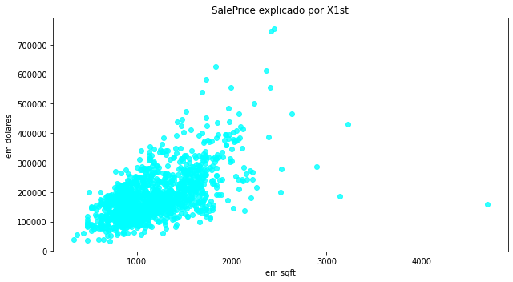

```python
fig = plt.figure(figsize=(9, 5))

plt.scatter(dados.X1stFlrSF, dados.SalePrice, c='cyan', alpha=0.8)
plt.title('SalePrice explicado por X1st')
plt.xlabel('em sqft')
plt.ylabel('em dolares')

plt.tight_layout()
plt.show()
```

**c)** Como você verificaria a seguinte afirmação: *Os imóveis sem ar central possuem a mesma qualidade geral de material e de acabamento quando comparados com imóveis que possuem ar central*?

Obs: Considere as variáveis `CentralAir` e `OverallQual` para responder a pergunta acima.

```python
#pode ser apenas tabela
ct2=(pd.crosstab(dados.CentralAir, dados.OverallQual, margins=False,
                 rownames=['Ar Central'], colnames=['Qualidade'], normalize='index')*100).round(decimals=2)
ct2
```

[output not shown]

[figure not shown]

```python
#pode ter grafico tambem mas não é obrigatório se a tabela for bem interpretada

plot = ct2.plot(kind='bar', stacked=True,title='Qualidade por Ar Central',figsize=(8, 6))
plt.ylabel('Freq.Relativa (em %)')

#Para legenda ficar fora do gráfico
ax = plt.subplot(111)
box = ax.get_position()
ax.set_position([box.x0, box.y0, box.width * 0.8, box.height])
ax.legend(loc='center left', bbox_to_anchor=(1, 0.5))

plt.show()
```